# BioBead Greenhouse Study Soil Analysis Project Overview

Renee Davis

2026-02-25

# Introduction

BioBead is a biodegradable hydrogel pellet containing fungal and bacterial consortia for soil health and regenerative agriculture. Microbes in this consortia can fix nitrogen (N), solubilize phosphorus (P), and drive carbon (C) cycling. Arbuscular mycorrhizal fungi (AMF) are obligate mutualists that make direct contact with plant roots and hand off N and P to plants, obtaining C in return. They also provide structures for microbial residence and travel. Greenhouse studies with BioBead have demonstrated improved growth for tomatoes and wheat plants, increases in soil organic matter, and promotion of closed nutrient cycling.

In 2025, a greenhouse study led by Renee Davis and Korena Mafune, PhD evaluated the impacts of 14 different microbe inoculations and treatments on soil microbiology, wheat growth, root colonization, and greenhouse gas emissions. This specific project will focus on soil geochemistry, nutrient dynamics, and soil moisture data, with other data being incorporated in subsequent phases. The responses measured at different intervals will have to be analyzed separately, or combined in another manner. These results will provide a foundation for expansion into larger field trials and BioBead formulation improvements in 2026 and beyond, and hopefully become publications and dissertation chapters.

# Methods

## Greenhouse Trial and Sample Collection

Wheat seedlings (Red Fife variety, Territorial Seeds) were planted in 1-gallon pots containing sunshine mix and sand (1:2 v/v) from September-December 2025 at the UW Biology Greenhouse. The experiment utilized a randomized design with 14 treatments and 7 biological replicates per treatment (98 pots total). Microbial inoculants were applied at planting according to treatment specifications.

Plants were grown for 14 weeks under greenhouse conditions. Plants were watered weekly with 200 mL water, and soil moisture was recorded 24 hours after each watering event. Leachate samples were collected at weeks 0, 2, 4, 6, 8 and analyzed using The Gallery (ThermoFisher) for ammonium, nitrate, and phosphate concentrations.

Plant Root Simulator (PRS) Probes (Western Ag Innovations) were buried at week 6 and retrieved after 14 days. Probes were sent to Western Ag for analysis of soil cation and anion exchange capacity via HPLC. At experiment termination (week 14), above-ground biomass was harvested and weighed, and rhizosphere soil and root samples were collected and stored at -80°C for future DNA extraction and metagenomic sequencing. (These data are mentioned for reference and will not be analyzed in this project.)

# Data

## Files

**2025biobeadgreenhouse.Rmd** - R Markdown file containing this document.

The data are compiled into a single spreadsheet (**2025greenhousemaster.csv**), which can be found in the [GitHub repository](https://github.com/reneeadeledavis/biobead). It was compiled from the following raw data.

- **Leachates_2025.csv** - Ammonium, nitrate, and phosphate leachate concentrations recorded throughout the study.
- **PRS_GH_2025.csv** - Soil anion and cation exchange data from PRS probes.
- **WheatMoistureData_2025.csv** - Soil moisture data recorded throughout the study.

**N2O_flux.data.csv** - Nitrous oxide (N2O) flux was also calculated. The data are limited to 3 replicates per treatment (not 7), so these data will remain in its own file rather than grafted to the master spreadsheet.

**Wheat yield data** has been added to the master spreadsheet, and includes 2 columns on grain yield (per sample unit) and an associated Harvest Index (HI), which is a ratio of grain yield over the rest of the above-ground biomass. It represents an economically-relevant measure of wheat crop productivity.

Exploratory one-way ANOVAs have already been performed on [leachate](https://rpubs.com/reneedavis/1389304), [soil moisture](https://rpubs.com/reneedavis/moisture2025), [anion/cation supply rate](https://rpubs.com/reneedavis/ions2025), [wheat yield](https://rpubs.com/reneedavis/wheatyield2025), and [N2O flux](https://rpubs.com/reneedavis/1392995).

## Response variables

| Code | Full Name | Units | Range |
| --- | --- | --- | --- |
| NH4-N_ugml | Ammonium | ug/mL | 0.01-5.24 |
| NO3-N_ugml | Nitrate | ug/mL | 0-97.55 |
| PO4-P_ugml | Phosphate | ug/mL | 0.05-31.97 |
| % soil moisture | Percent Soil Moisture | n/a | 0-100 |
| NO3-N | Nitrate | ug/10cm<sup>2</sup>/14 days | 0.8-8.3 |
| NH4-N | Ammonium | ug/10cm<sup>2</sup>/14 days | 0-2.9 |
| P | Phosphorus | ug/10cm<sup>2</sup>/14 days | 6.8-23.7 |
| Ca | Calcium | ug/10cm<sup>2</sup>/14 days | 751-2220 |
| Mg | Magnesium | ug/10cm<sup>2</sup>/14 days | 158-477 |
| K | Potassium | ug/10cm<sup>2</sup>/14 days | 146-305 |
| Fe | Iron | ug/10cm<sup>2</sup>/14 days | 2.5-21.5 |
| Mn | Manganese | ug/10cm<sup>2</sup>/14 days | 0.3-1.5 |
| Cu | Copper | ug/10cm<sup>2</sup>/14 days | 0-1 |
| Zn | Zinc | ug/10cm<sup>2</sup>/14 days | 1.3-3.8 |
| B | Boron | ug/10cm<sup>2</sup>/14 days | 0-0.6 |
| S | Sulphur | ug/10cm<sup>2</sup>/14 days | 105-490 |
| Pb | Lead | ug/10cm<sup>2</sup>/14 days | 0-0.9 |
| Al | Aluminum | ug/10cm<sup>2</sup>/14 days | 3.4-9.5 |
| Cd | Cadmium | ug/10cm<sup>2</sup>/14 days | 0-0.2 |
| Na | Sodium | ug/10cm<sup>2</sup>/14 days | 943-2734 |

## Explanatory variables

[output not shown]

## Treatment codes

T1 - BioBead – bacteria

T2 - BioBead – AMF

T3 - BioBead - bacteria, AMF

T4 - SL-primed BioBead - bacteria, AMF

T5 - SL-primed BioBead - bacteria

T6 - SL-primed BioBead - AMF

T7 - BioBead w/ reapplication at week 8

T8 - ½ fertilizer ½ BioBead

T9 - Liquid consortia

T10 - Commercial biofertilizer (Hardygro)

T11 - Empty bead

T12 - SL-primed empty bead

T13 - Synthetic fertilizer (positive control – 10% dose, 0.6 g/L, 10mL/pot)

T14 - Untreated

Specific replicates of samples are indicated after a dash in the sample code. For example, certain replicates in the PRS data are designated as T1-1, T1-2, T1-3, etc.

# Exploratory NMDS

## Soil Properties NMDS

```r
# load in data
library(vegan)
```

```r
data <- read.csv("2025greenhousemaster.csv", header = TRUE, row.names = 1)
ions <- read.csv("ions/PRS_2025.csv", header = TRUE)

# Subset response and explanatory variables
treatments <- data$Treatment_Category
soil_properties <- data[ , !colnames(data) %in% "Treatment_Category"]
soil_properties_rel <- decostand(soil_properties, method = "max") ## Relativize by column maxima

# create Euclidean distance matrix
data_dist <- vegdist(soil_properties_rel, method = "euclidean")

nmds_result <- metaMDS(soil_properties_rel,
                       distance = "euclidean",
                       k = 3,
                       trymax = 100)
```

```
## 'comm' has negative data: 'autotransform', 'noshare' and 'wascores' set to FALSE
```

```
## *** Best solution repeated 8 times
```

```r
nmds_result$stress
```

```
## [1] 0.05163808
```

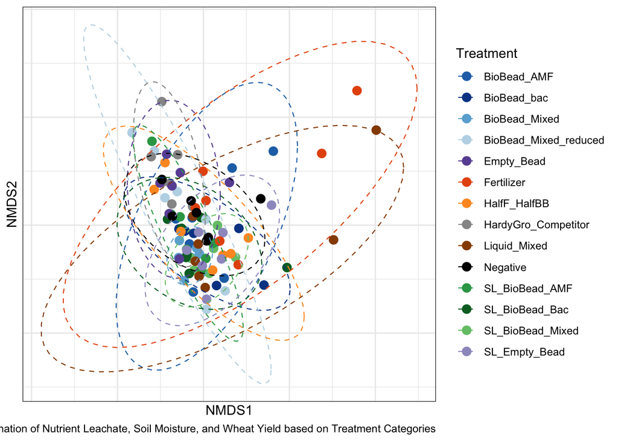

```r
#create data frame
nmds_scores <- as.data.frame(scores(nmds_result, display = "sites"))
nmds_scores$Treatment <- treatments

# color palette
treatment_colors <- c(
  "BioBead_bac"             = "#084594",  # dark blue
  "BioBead_AMF"             = "#2171b5",  # mid blue
  "BioBead_Mixed"           = "#6baed6",  # light blue
  "BioBead_Mixed_reduced"   = "#bdd7e7",  # very light blue (underdosed)

  "SL_BioBead_Bac"          = "#006d2c",  # dark green
  "SL_BioBead_AMF"          = "#31a354",  # mid green
  "SL_BioBead_Mixed"        = "#74c476",  # light green

  "Empty_Bead"              = "#6a51a3",  # dark purple
  "SL_Empty_Bead"           = "#9e9ac8",  # light purple

  "HalfF_HalfBB"            = "#fe9929",  # orange (bridge between BB and fert)
  "Liquid_Mixed"            = "#964B00",  # brown
  "HardyGro_Competitor"     = "#969696",  # gray

  "Fertilizer"              = "#e6550d",  # red-orange (positive control)
  "Negative"                = "#000000"   # black (negative control)
)

#plot
library(ggplot2)
p1 <- ggplot(nmds_scores, aes(x = NMDS1, y = NMDS2, color = Treatment)) +
  geom_point(size = 3) +
  scale_color_manual(values = treatment_colors) +
  stat_ellipse(aes(group = Treatment), level = 0.95, linetype = "dashed", linewidth = 0.4) +  # potentially correct to ggforce (below), this assumes normal dist
  theme_bw() +
  theme(axis.ticks = element_blank(),
        axis.text = element_blank()) +
  labs(x = "NMDS1", y = "NMDS2",
       caption = "Figure 1: NMDS Ordination of Nutrient Leachate, Soil Moisture, and Wheat Yield based on Treatment Categories")

p1
```